# HAS: Qualtrics Demographic

## STAI

State-Trait Inventory for Adults (STAI) measures participant’s anxiety

**STATE:** current level of anxiety

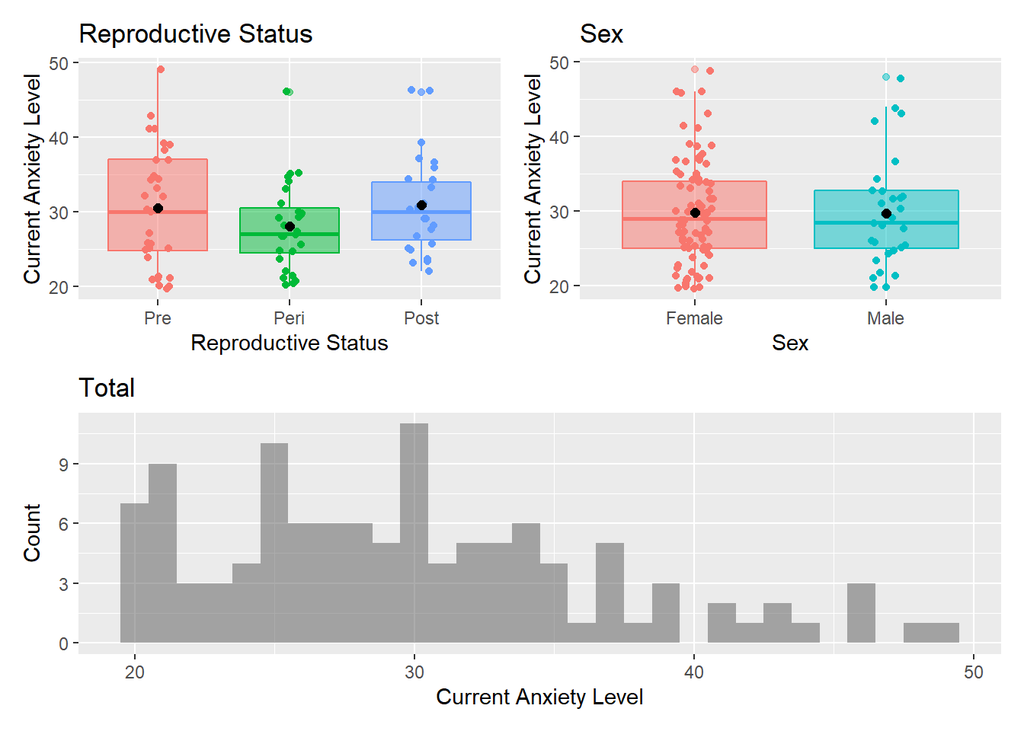

**TRAIT:** general level of anxiety

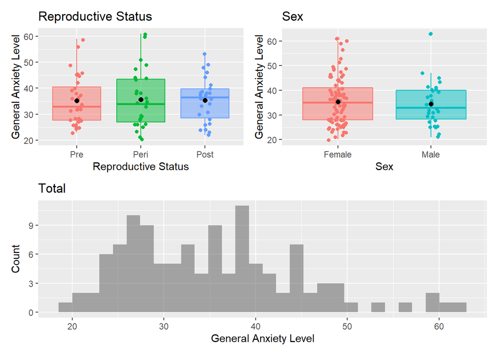

Generally, anxiety levels seem higher. Will COVID also influence current and general forms of anxiety?

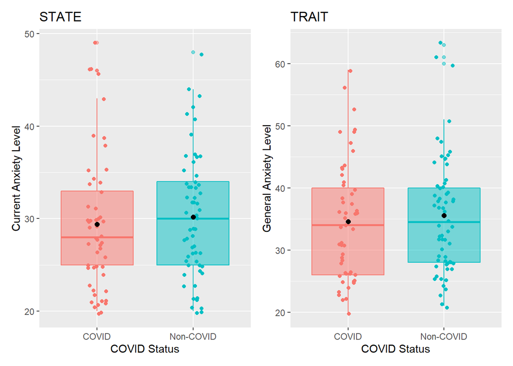

No differences for either STATE or TRAIT between groups.

# Face Name Memory

## Name Learning and Retrieval

Name Learning & Retrieving Composite of:

- Initial recall of names (1st and 2nd rounds)
- Cued recall of names after 2 trials

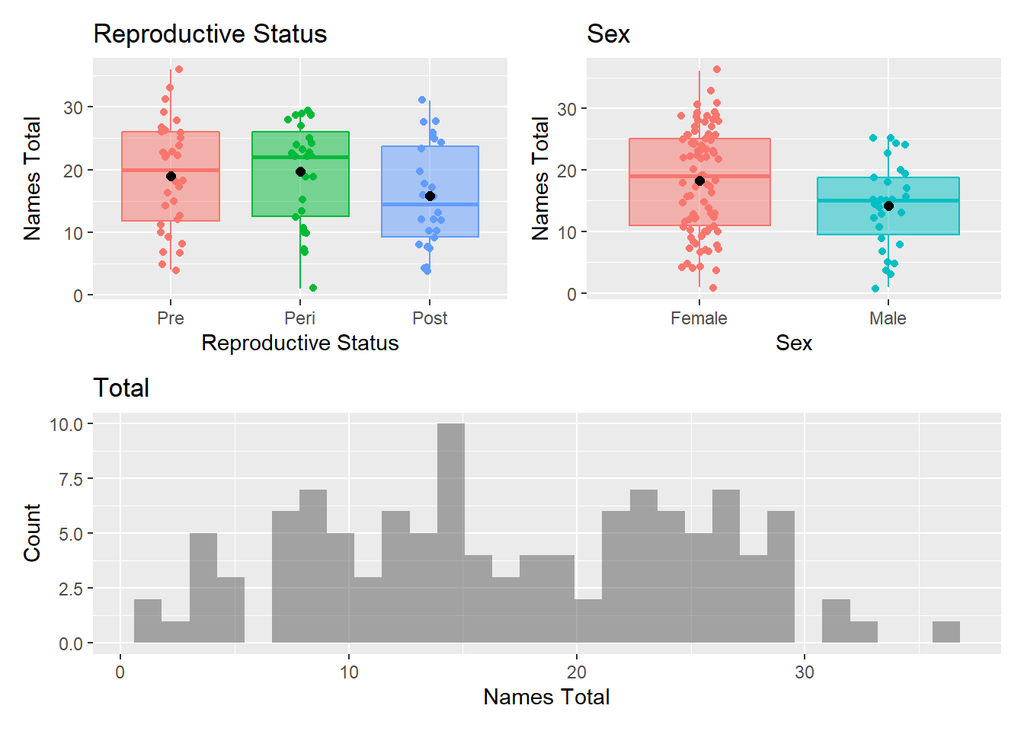

## Occupation Learning and Retrieval

Occupation Learning & Retrieving Composite

- Initial recall of occupations (1st and 2nd rounds)
- Cued recall of occupations after 2 trials

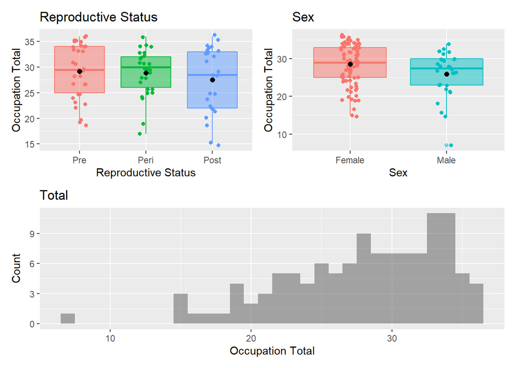

## Composite Name and Occupation

Composite of Name and Occupation Learning and Recall (Total)

Sum of FNAME-NT and FNAME OT

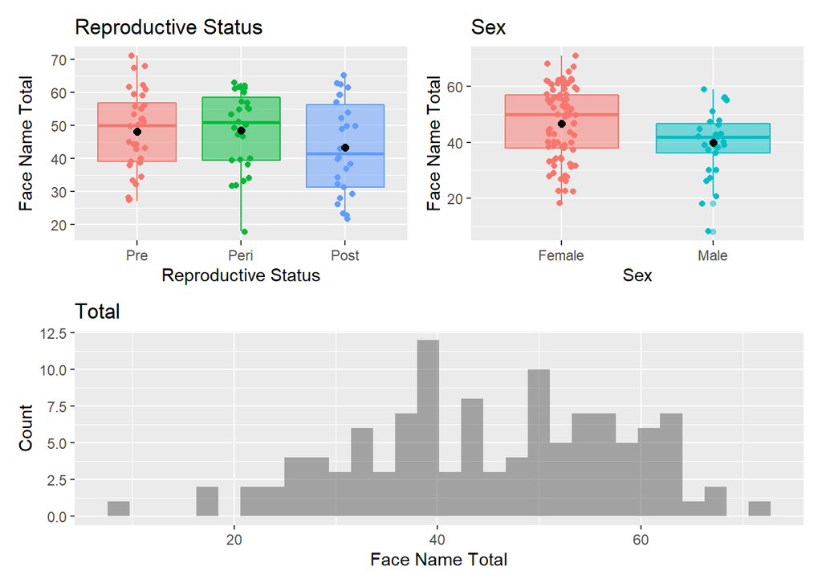